# MLM Intuitions, Implementation in R, Random Slopes

## 5.2 What about approximate normality of random effects?

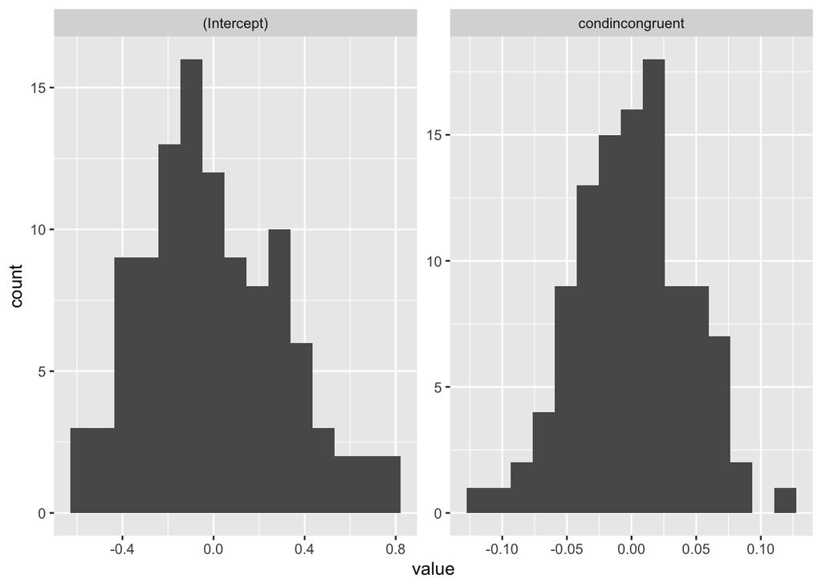

```r
rr <- ranef(m3)$id %>% pivot_longer(cols=everything())

ggplot(rr, aes(x=value)) + geom_histogram(bins=15) +
  facet_wrap(~name, scales="free")
```

Not too bad. One of our assumptions in MLM is that the random effects are distributed as (approximately) multivariate normal. Here, I’ve plotted the univariate distributions. We would also perhaps want to check that the bivariate distribution is approximately normal.

If you really want to get fancy, you could formally test for multivariate normality using the `MVN` package, though this is overkill for most applications.

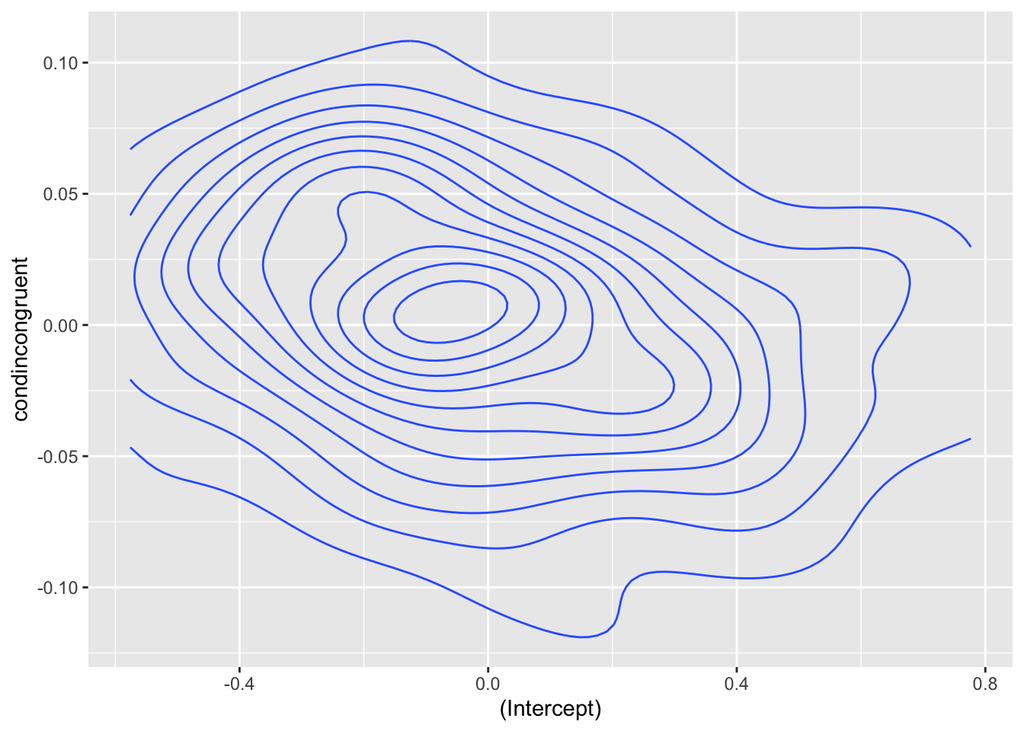

```r
ggplot(ranef(m3)$id, aes(x=`(Intercept)`, y=condincongruent)) + geom_density_2d()
```